# Analise de Kilometragem por peso

Julio Cesar Marques

2022-07-12

# **Objetivo:** Analisar Kilometro rodado por peso

**Descrição:**

O Aplicativo consiste na visualização gráfica e tabela de detalhes para analise de kilometro rodado por peso, com iteração do usuário na definição de quantidade de pontos de visualização e seleção da area de observação em detalhes.

# 1. Dados de exploração

*A conjunto de dados utilizado para exploração será a,* **mtcars** *disponível em (R).*

## 1.1 história do conjunto de dados

*Os dados foram extraídos da revista Motor Trend US de 1974 e abrangem o consumo de combustível e 10 aspectos do design e desempenho do automóvel para 32 automóveis (modelos de 1973 a 74). Os mesmos desde então foram disponibilizados na base R para treinamentos e estudos.*

### 1.1.1 Descrição das variáveis, em negrito aplicado em nosso app:

**mpg = Milhas/(EUA) galão**

cyl = numero de cilindros

disp = Deslocamento (cu.in.)

hp = Potência bruta

drat = Relação do eixo traseiro

**wt = Peso (1000 libras)**

qsec = tempo de 1/4 de milha

vs = Motor (0 = em forma de V, 1 = reto)

am = Transmissão (0 = automática, 1 = manual)

gear = Número de marchas para frente

### 1.1.2 Segue uma leitura abaixo com algumas amostras do conjunto de dados:

registros:

```r
nrow(mtcars)
```

```
[1] 32
```

```r
head(mtcars)
```

```
                   mpg cyl disp  hp drat    wt  qsec vs am gear carb
Mazda RX4         21.0   6  160 110 3.90 2.620 16.46  0  1    4    4
Mazda RX4 Wag     21.0   6  160 110 3.90 2.875 17.02  0  1    4    4
Datsun 710        22.8   4  108  93 3.85 2.320 18.61  1  1    4    1
Hornet 4 Drive    21.4   6  258 110 3.08 3.215 19.44  1  0    3    1
Hornet Sportabout 18.7   8  360 175 3.15 3.440 17.02  0  0    3    2
Valiant           18.1   6  225 105 2.76 3.460 20.22  1  0    3    1
```

# 2. Entradas e Saidas

## 2.1 Funcionalidades

**Painel (Entradas):**

- Seletor númerico, o usuário poderá definir quantos pontos(carros) queremos visualizar no grárico, sendo este por default a quantidade de registros do conjunto de dados.
- Entrada deslisante (Largura mínimo e máximo para eixo X), sendo este definido para visualização de **largura** do gráfico.
- Entrada deslisante (Altura mínimo e máximo para eixo Y), sendo este definido para visualização de **altura** do gráfico.
- Check box, para ocultar/visualizar o título.

# **Gráfico utilizado para demosntração de pontos aleatórios**

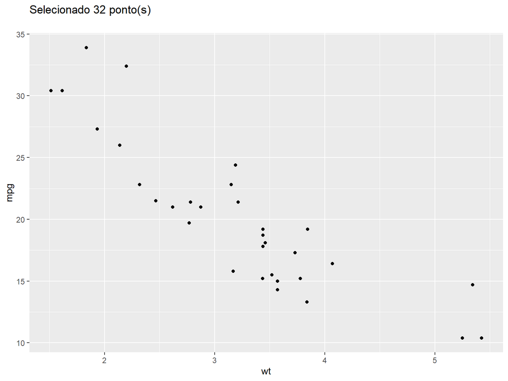

```r
require(ggplot2)
      numeric <- nrow(mtcars)
      ggplot(mtcars[sample(x=1:nrow(mtcars), size = numeric),], aes(wt, mpg)) +   geom_point() +
        labs(title='Selecionado 32 ponto(s)\n')
```

# **Seleção da area do gráfico (Saídas):**

Uma das funcionalidade da aplicação é a opção de selecionar area especifica do gráfico e obter detalhes dos pontos em uma tabela de resultado abaixo.

Este exemplo mostra a base completa mas imagina que estivessemos filtrando o dado através da seleção de alguns pontos no gráfico, este teria a condição entre wt e entre mpg.

```r
    numeric <- nrow(mtcars)
    df <- mtcars[sample(x=1:nrow(mtcars), size = numeric),]
    return(df)
```

```
                     mpg cyl  disp  hp drat    wt  qsec vs am gear carb
Ferrari Dino        19.7   6 145.0 175 3.62 2.770 15.50  0  1    5    6
Merc 450SE          16.4   8 275.8 180 3.07 4.070 17.40  0  0    3    3
Pontiac Firebird    19.2   8 400.0 175 3.08 3.845 17.05  0  0    3    2
Toyota Corolla      33.9   4  71.1  65 4.22 1.835 19.90  1  1    4    1
Maserati Bora       15.0   8 301.0 335 3.54 3.570 14.60  0  1    5    8
Fiat 128            32.4   4  78.7  66 4.08 2.200 19.47  1  1    4    1
Fiat X1-9           27.3   4  79.0  66 4.08 1.935 18.90  1  1    4    1
Lincoln Continental 10.4   8 460.0 215 3.00 5.424 17.82  0  0    3    4
Toyota Corona       21.5   4 120.1  97 3.70 2.465 20.01  1  0    3    1
Merc 240D           24.4   4 146.7  62 3.69 3.190 20.00  1  0    4    2
Cadillac Fleetwood  10.4   8 472.0 205 2.93 5.250 17.98  0  0    3    4
Merc 450SLC         15.2   8 275.8 180 3.07 3.780 18.00  0  0    3    3
Merc 280            19.2   6 167.6 123 3.92 3.440 18.30  1  0    4    4
Chrysler Imperial   14.7   8 440.0 230 3.23 5.345 17.42  0  0    3    4
Datsun 710          22.8   4 108.0  93 3.85 2.320 18.61  1  1    4    1
Merc 450SL          17.3   8 275.8 180 3.07 3.730 17.60  0  0    3    3
AMC Javelin         15.2   8 304.0 150 3.15 3.435 17.30  0  0    3    2
Lotus Europa        30.4   4  95.1 113 3.77 1.513 16.90  1  1    5    2
Hornet 4 Drive      21.4   6 258.0 110 3.08 3.215 19.44  1  0    3    1
Merc 280C           17.8   6 167.6 123 3.92 3.440 18.90  1  0    4    4
Valiant             18.1   6 225.0 105 2.76 3.460 20.22  1  0    3    1
Duster 360          14.3   8 360.0 245 3.21 3.570 15.84  0  0    3    4
Hornet Sportabout   18.7   8 360.0 175 3.15 3.440 17.02  0  0    3    2
Mazda RX4           21.0   6 160.0 110 3.90 2.620 16.46  0  1    4    4
Volvo 142E          21.4   4 121.0 109 4.11 2.780 18.60  1  1    4    2
Honda Civic         30.4   4  75.7  52 4.93 1.615 18.52  1  1    4    2
Mazda RX4 Wag       21.0   6 160.0 110 3.90 2.875 17.02  0  1    4    4
Camaro Z28          13.3   8 350.0 245 3.73 3.840 15.41  0  0    3    4
Porsche 914-2       26.0   4 120.3  91 4.43 2.140 16.70  0  1    5    2
Ford Pantera L      15.8   8 351.0 264 4.22 3.170 14.50  0  1    5    4
Dodge Challenger    15.5   8 318.0 150 2.76 3.520 16.87  0  0    3    2
Merc 230            22.8   4 140.8  95 3.92 3.150 22.90  1  0    4    2
```